# Intro to dplyr - Lab

```r
#library(tidyverse)
library(dplyr)
```

```r
library(magrittr)
library(ggplot2)
```

## Dplyr practice

Install the `"nycflights13"` package. Load (`library()`) the package. You’ll also need to load `tidyverse` The data frame called `flights` should now be accessible to you.

```r
# install.packages("nycflights13") # once per computer
library(nycflights13) # every time you use it
#library(tidyverse)

my_flights <- flights ## getting a copy of the data in the environment
```

1. Use functions to inspect it: how many rows and columns does it have? What are the names of the columns? Hint: Use `??flights` to search for documentation on the data set (for what the columns contain)

```r
nrow(my_flights)
```

```
## [1] 336776
```

```r
ncol(my_flights)
```

```
## [1] 19
```

```r
colnames(my_flights)
```

```
##  [1] "year"           "month"          "day"            "dep_time"
##  [5] "sched_dep_time" "dep_delay"      "arr_time"       "sched_arr_time"
##  [9] "arr_delay"      "carrier"        "flight"         "tailnum"
## [13] "origin"         "dest"           "air_time"       "distance"
## [17] "hour"           "minute"         "time_hour"
```

```r
glimpse(my_flights)
```

```
## Rows: 336,776
## Columns: 19
## $ year           <int> 2013, 2013, 2013, 2013, 2013, 2013, 2013, 2013, 2013, 2…
## $ month          <int> 1, 1, 1, 1, 1, 1, 1, 1, 1, 1, 1, 1, 1, 1, 1, 1, 1, 1, 1…
## $ day            <int> 1, 1, 1, 1, 1, 1, 1, 1, 1, 1, 1, 1, 1, 1, 1, 1, 1, 1, 1…
## $ dep_time       <int> 517, 533, 542, 544, 554, 554, 555, 557, 557, 558, 558, …
## $ sched_dep_time <int> 515, 529, 540, 545, 600, 558, 600, 600, 600, 600, 600, …
## $ dep_delay      <dbl> 2, 4, 2, -1, -6, -4, -5, -3, -3, -2, -2, -2, -2, -2, -1…
## $ arr_time       <int> 830, 850, 923, 1004, 812, 740, 913, 709, 838, 753, 849,…
## $ sched_arr_time <int> 819, 830, 850, 1022, 837, 728, 854, 723, 846, 745, 851,…
## $ arr_delay      <dbl> 11, 20, 33, -18, -25, 12, 19, -14, -8, 8, -2, -3, 7, -1…
## $ carrier        <chr> "UA", "UA", "AA", "B6", "DL", "UA", "B6", "EV", "B6", "…
## $ flight         <int> 1545, 1714, 1141, 725, 461, 1696, 507, 5708, 79, 301, 4…
## $ tailnum        <chr> "N14228", "N24211", "N619AA", "N804JB", "N668DN", "N394…
## $ origin         <chr> "EWR", "LGA", "JFK", "JFK", "LGA", "EWR", "EWR", "LGA",…
## $ dest           <chr> "IAH", "IAH", "MIA", "BQN", "ATL", "ORD", "FLL", "IAD",…
## $ air_time       <dbl> 227, 227, 160, 183, 116, 150, 158, 53, 140, 138, 149, 1…
## $ distance       <dbl> 1400, 1416, 1089, 1576, 762, 719, 1065, 229, 944, 733, …
## $ hour           <dbl> 5, 5, 5, 5, 6, 5, 6, 6, 6, 6, 6, 6, 6, 6, 6, 5, 6, 6, 6…
## $ minute         <dbl> 15, 29, 40, 45, 0, 58, 0, 0, 0, 0, 0, 0, 0, 0, 0, 59, 0…
## $ time_hour      <dttm> 2013-01-01 05:00:00, 2013-01-01 05:00:00, 2013-01-01 0…
```

2. Use `dplyr` to give the data frame a new column that is the amount of time gained or lost while flying (that is: how much of the delay arriving occurred during flight, as opposed to before departing).

```r
my_flights <- my_flights %>%
  mutate(time_gained_or_lost = arr_delay - dep_delay)
head(my_flights)
```

```
## # A tibble: 6 × 20
##    year month   day dep_time sched_dep_time dep_delay arr_time sched_arr_time
##   <int> <int> <int>    <int>          <int>     <dbl>    <int>          <int>
## 1  2013     1     1      517            515         2      830            819
## 2  2013     1     1      533            529         4      850            830
## 3  2013     1     1      542            540         2      923            850
## 4  2013     1     1      544            545        -1     1004           1022
## 5  2013     1     1      554            600        -6      812            837
## 6  2013     1     1      554            558        -4      740            728
## # ℹ 12 more variables: arr_delay <dbl>, carrier <chr>, flight <int>,
## #   tailnum <chr>, origin <chr>, dest <chr>, air_time <dbl>, distance <dbl>,
## #   hour <dbl>, minute <dbl>, time_hour <dttm>, time_gained_or_lost <dbl>
```

3. Use `dplyr` to sort your data frame in descending order by the column you just created. Remember to save this as a variable (or in the same one!)

```r
my_flight <- my_flights %>% arrange(desc(time_gained_or_lost))
head(my_flight)
```

```
## # A tibble: 6 × 20
##    year month   day dep_time sched_dep_time dep_delay arr_time sched_arr_time
##   <int> <int> <int>    <int>          <int>     <dbl>    <int>          <int>
## 1  2013    11     1      658            700        -2     1329           1015
## 2  2013     4    18      558            600        -2     1149            850
## 3  2013     8     8     1819           1519       180        5           1820
## 4  2013     7    10     1916           1900        16      137           2240
## 5  2013     6    27     1608           1525        43     2045           1725
## 6  2013     7    22     1606           1615        -9     2056           1831
## # ℹ 12 more variables: arr_delay <dbl>, carrier <chr>, flight <int>,
## #   tailnum <chr>, origin <chr>, dest <chr>, air_time <dbl>, distance <dbl>,
## #   hour <dbl>, minute <dbl>, time_hour <dttm>, time_gained_or_lost <dbl>
```

4. If you haven’t already, do the last 2 steps in a single statement using the pipe operator.

```r
my_flights <- my_flights %>%
  mutate(time_gained_or_lost = arr_delay - dep_delay) %>% arrange(desc(time_gained_or_lost))

head(my_flights)
```

```
## # A tibble: 6 × 20
##    year month   day dep_time sched_dep_time dep_delay arr_time sched_arr_time
##   <int> <int> <int>    <int>          <int>     <dbl>    <int>          <int>
## 1  2013    11     1      658            700        -2     1329           1015
## 2  2013     4    18      558            600        -2     1149            850
## 3  2013     8     8     1819           1519       180        5           1820
## 4  2013     7    10     1916           1900        16      137           2240
## 5  2013     6    27     1608           1525        43     2045           1725
## 6  2013     7    22     1606           1615        -9     2056           1831
## # ℹ 12 more variables: arr_delay <dbl>, carrier <chr>, flight <int>,
## #   tailnum <chr>, origin <chr>, dest <chr>, air_time <dbl>, distance <dbl>,
## #   hour <dbl>, minute <dbl>, time_hour <dttm>, time_gained_or_lost <dbl>
```

5. Make a histogram of the amount of time gained using the `hist()` function

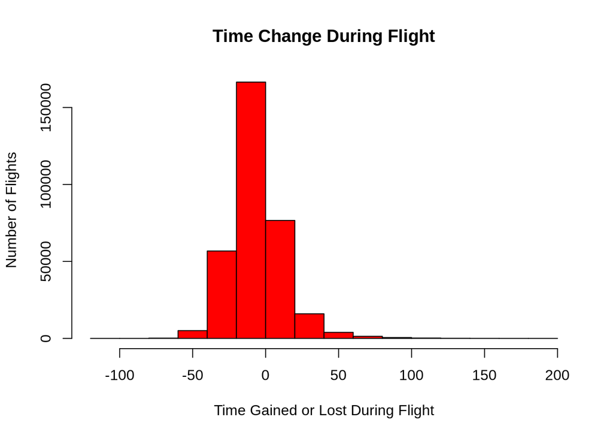

```r
hist(my_flights$time_gained_or_lost,
     xlab = "Time Gained or Lost During Flight",
     ylab = "Number of Flights",
     main = "Time Change During Flight",
     col = "red")
```

6. On average, did flights gain or lose time? Note: use the `na.rm = TRUE` argument to remove NA values from your aggregation

```r
average_time_change <- my_flights %>%
  summarise(mean_time_change = mean(time_gained_or_lost, na.rm = TRUE))

average_time_change
```

```
## # A tibble: 1 × 1
##   mean_time_change
##              <dbl>
## 1            -5.66
```

7. Create a data.frame of flights with a destination of Hobby Airport (Airport code ‘HOU’), only including the origin, destination, and the “made_up_time” column you just created

```r
#Hobby_Airport <- my_flights %>% filter(dest == 'HOU')%>% select(origin, dest,my_flights)
Hobby_Airport <- my_flights %>%
  filter(dest == "HOU") %>%
  select(origin, dest, time_gained_or_lost)
```

```r
#sea_average_time_change <- flights_with_time_change %>%

 # filter(dest == "SEA") %>%
  #summarise(mean_time_change = mean(time_gained_or_lost, na.rm = TRUE))

#sea_average_time_change
```

## Exercise:

Go back to our flights exercise data. Consider flights from JFK to SEA. What was the average, min, and max air time of those flights? Use pipes to answer this question in one statement (without showing any other data)!

```r
flights %>%
  filter(origin == "JFK", dest == "SEA") %>%
  summarise(
    avg_air_time = mean(air_time, na.rm = TRUE),
    min_air_time = min(air_time, na.rm = TRUE),
    max_air_time = max(air_time, na.rm = TRUE)
  )
```

```
## # A tibble: 1 × 3
##   avg_air_time min_air_time max_air_time
##          <dbl>        <dbl>        <dbl>
## 1         329.          275          389
```

Consider flights coming into Houston (HOU and IAH). What is the mean arrival delay by departure airport?

```r
houston_delays <- flights %>%
  filter(dest %in% c("HOU", "IAH")) %>%
  group_by(origin) %>%
  summarise(mean_arr_delay = mean(arr_delay, na.rm = TRUE))


print(houston_delays)
```

```
## # A tibble: 3 × 2
##   origin mean_arr_delay
##   <chr>           <dbl>
## 1 EWR              6.23
## 2 JFK             10.3
## 3 LGA              1.37
```

Getting ready for next class: Create a list of all the different values for the destination airport.

```r
unique_destinations <- unique(flights$dest)
unique_destinations
```

```
##   [1] "IAH" "MIA" "BQN" "ATL" "ORD" "FLL" "IAD" "MCO" "PBI" "TPA" "LAX" "SFO"
##  [13] "DFW" "BOS" "LAS" "MSP" "DTW" "RSW" "SJU" "PHX" "BWI" "CLT" "BUF" "DEN"
##  [25] "SNA" "MSY" "SLC" "XNA" "MKE" "SEA" "ROC" "SYR" "SRQ" "RDU" "CMH" "JAX"
##  [37] "CHS" "MEM" "PIT" "SAN" "DCA" "CLE" "STL" "MYR" "JAC" "MDW" "HNL" "BNA"
##  [49] "AUS" "BTV" "PHL" "STT" "EGE" "AVL" "PWM" "IND" "SAV" "CAK" "HOU" "LGB"
##  [61] "DAY" "ALB" "BDL" "MHT" "MSN" "GSO" "CVG" "BUR" "RIC" "GSP" "GRR" "MCI"
##  [73] "ORF" "SAT" "SDF" "PDX" "SJC" "OMA" "CRW" "OAK" "SMF" "TUL" "TYS" "OKC"
##  [85] "PVD" "DSM" "PSE" "BHM" "CAE" "HDN" "BZN" "MTJ" "EYW" "PSP" "ACK" "BGR"
##  [97] "ABQ" "ILM" "MVY" "SBN" "LEX" "CHO" "TVC" "ANC" "LGA"
```

Hmm… I don’t know about you, but it sure does seem like there are some values here I don’t recognize!

## Lab for the day:

In the package `dplyr` there is a dataset called `starwars`.

```r
glimpse(starwars)
```

```
## Rows: 87
## Columns: 14
## $ name       <chr> "Luke Skywalker", "C-3PO", "R2-D2", "Darth Vader", "Leia Or…
## $ height     <int> 172, 167, 96, 202, 150, 178, 165, 97, 183, 182, 188, 180, 2…
## $ mass       <dbl> 77.0, 75.0, 32.0, 136.0, 49.0, 120.0, 75.0, 32.0, 84.0, 77.…
## $ hair_color <chr> "blond", NA, NA, "none", "brown", "brown, grey", "brown", N…
## $ skin_color <chr> "fair", "gold", "white, blue", "white", "light", "light", "…
## $ eye_color  <chr> "blue", "yellow", "red", "yellow", "brown", "blue", "blue",…
## $ birth_year <dbl> 19.0, 112.0, 33.0, 41.9, 19.0, 52.0, 47.0, NA, 24.0, 57.0, …
## $ sex        <chr> "male", "none", "none", "male", "female", "male", "female",…
## $ gender     <chr> "masculine", "masculine", "masculine", "masculine", "femini…
## $ homeworld  <chr> "Tatooine", "Tatooine", "Naboo", "Tatooine", "Alderaan", "T…
## $ species    <chr> "Human", "Droid", "Droid", "Human", "Human", "Human", "Huma…
## $ films      <list> <"A New Hope", "The Empire Strikes Back", "Return of the J…
## $ vehicles   <list> <"Snowspeeder", "Imperial Speeder Bike">, <>, <>, <>, "Imp…
## $ starships  <list> <"X-wing", "Imperial shuttle">, <>, <>, "TIE Advanced x1",…
```

We’re going to use this to practice some data wrangling with `dplyr`.

First, we filter by species to only see the humans, and use that subset to plot a scatter plot of their height and mass.

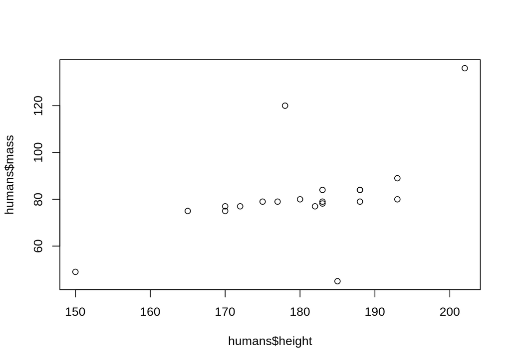

```r
humans <- starwars %>% filter(species == "Human")
plot(humans$height, humans$mass)
```

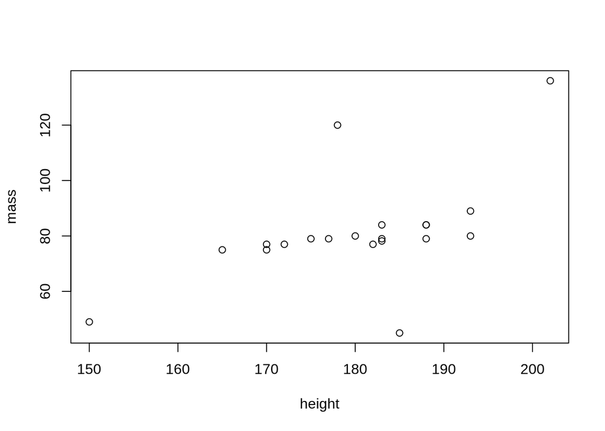

```r
starwars %>% filter(species == "Human") %>% plot(mass ~ height, data = .)
```

Now, change this to see the same plot for the Droids.

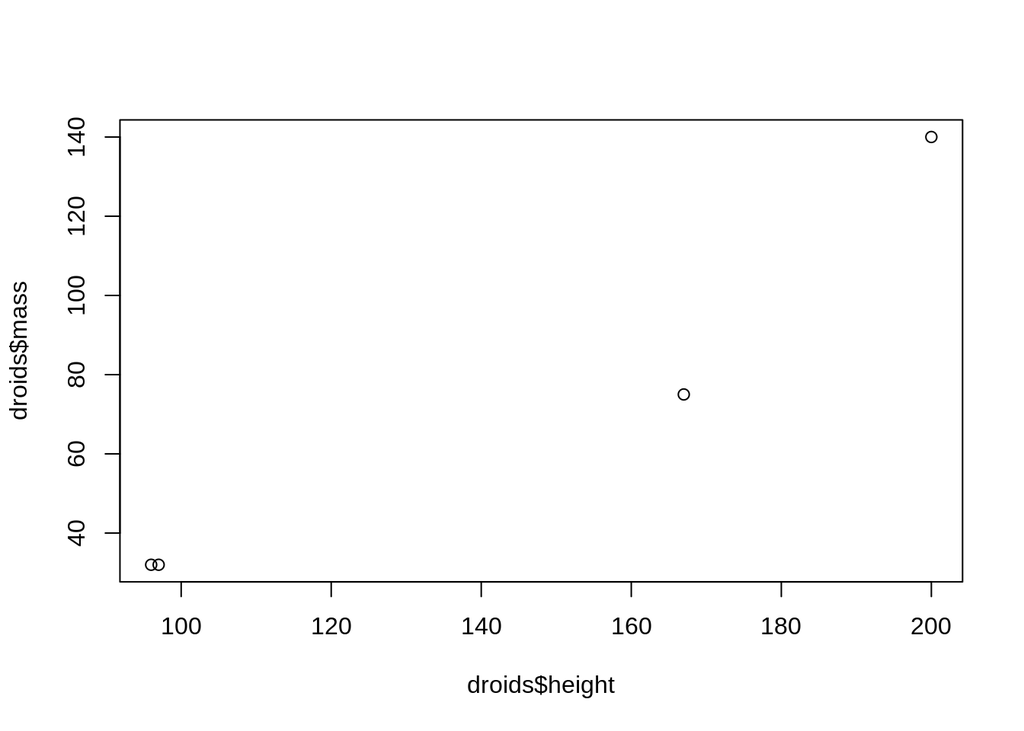

```r
droids <- starwars %>% filter(species == "Droid")
plot(droids$height, droids$mass)
```

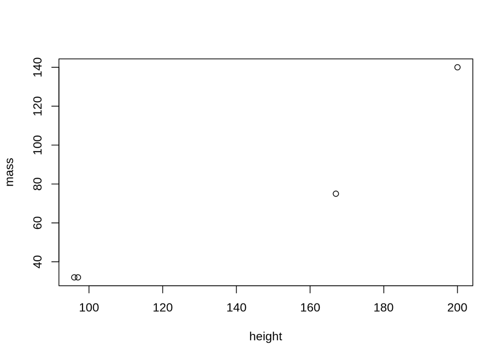

```r
starwars %>% filter(species == "Droid") %>% plot(mass ~ height, data = .)
```

How many characters are from each planet?

```r
starwars %>% select(name, homeworld) %>% count(homeworld)
```

```
## # A tibble: 49 × 2
##    homeworld          n
##    <chr>          <int>
##  1 Alderaan           3
##  2 Aleen Minor        1
##  3 Bespin             1
##  4 Bestine IV         1
##  5 Cato Neimoidia     1
##  6 Cerea              1
##  7 Champala           1
##  8 Chandrila          1
##  9 Concord Dawn       1
## 10 Corellia           2
## # ℹ 39 more rows
```

If you wanted to arrange this in descending order, what would you add to the pipe?

```r
starwars %>% select(name, homeworld) %>% count(homeworld) %>% arrange(desc(n))
```

```
## # A tibble: 49 × 2
##    homeworld     n
##    <chr>     <int>
##  1 Naboo        11
##  2 Tatooine     10
##  3 <NA>         10
##  4 Alderaan      3
##  5 Coruscant     3
##  6 Kamino        3
##  7 Corellia      2
##  8 Kashyyyk      2
##  9 Mirial        2
## 10 Ryloth        2
## # ℹ 39 more rows
```

Find the average height for each eye color. You might find some of the answers to be strange, but keep going!

```r
starwars %>% group_by(eye_color) %>% summarize(mean=mean(height, na.rm=TRUE))
```

```
## # A tibble: 15 × 2
##    eye_color      mean
##    <chr>         <dbl>
##  1 black          185
##  2 blue           182.
##  3 blue-gray      182
##  4 brown          167.
##  5 dark           NaN
##  6 gold           191
##  7 green, yellow  216
##  8 hazel          174
##  9 orange         180.
## 10 pink           180
## 11 red            155.
## 12 red, blue       96
## 13 unknown        136
## 14 white          178
## 15 yellow         178.
```

```r
glimpse(starwars)
```

```
## Rows: 87
## Columns: 14
## $ name       <chr> "Luke Skywalker", "C-3PO", "R2-D2", "Darth Vader", "Leia Or…
## $ height     <int> 172, 167, 96, 202, 150, 178, 165, 97, 183, 182, 188, 180, 2…
## $ mass       <dbl> 77.0, 75.0, 32.0, 136.0, 49.0, 120.0, 75.0, 32.0, 84.0, 77.…
## $ hair_color <chr> "blond", NA, NA, "none", "brown", "brown, grey", "brown", N…
## $ skin_color <chr> "fair", "gold", "white, blue", "white", "light", "light", "…
## $ eye_color  <chr> "blue", "yellow", "red", "yellow", "brown", "blue", "blue",…
## $ birth_year <dbl> 19.0, 112.0, 33.0, 41.9, 19.0, 52.0, 47.0, NA, 24.0, 57.0, …
## $ sex        <chr> "male", "none", "none", "male", "female", "male", "female",…
## $ gender     <chr> "masculine", "masculine", "masculine", "masculine", "femini…
## $ homeworld  <chr> "Tatooine", "Tatooine", "Naboo", "Tatooine", "Alderaan", "T…
## $ species    <chr> "Human", "Droid", "Droid", "Human", "Human", "Human", "Huma…
## $ films      <list> <"A New Hope", "The Empire Strikes Back", "Return of the J…
## $ vehicles   <list> <"Snowspeeder", "Imperial Speeder Bike">, <>, <>, <>, "Imp…
## $ starships  <list> <"X-wing", "Imperial shuttle">, <>, <>, "TIE Advanced x1",…
```

```r
starwars %>% filter(eye_color == 'brown')
```

```
## # A tibble: 21 × 14
##    name     height  mass hair_color skin_color eye_color birth_year sex   gender
##    <chr>     <int> <dbl> <chr>      <chr>      <chr>          <dbl> <chr> <chr>
##  1 Leia Or…    150  49   brown      light      brown           19   fema… femin…
##  2 Biggs D…    183  84   black      light      brown           24   male  mascu…
##  3 Han Solo    180  80   brown      fair       brown           29   male  mascu…
##  4 Yoda         66  17   white      green      brown          896   male  mascu…
##  5 Boba Fe…    183  78.2 black      fair       brown           31.5 male  mascu…
##  6 Lando C…    177  79   black      dark       brown           31   male  mascu…
##  7 Arvel C…     NA  NA   brown      fair       brown           NA   male  mascu…
##  8 Wicket …     88  20   brown      brown      brown            8   male  mascu…
##  9 Padmé A…    185  45   brown      light      brown           46   fema… femin…
## 10 Quarsh …    183  NA   black      dark       brown           62   male  mascu…
## # ℹ 11 more rows
## # ℹ 5 more variables: homeworld <chr>, species <chr>, films <list>,
## #   vehicles <list>, starships <list>
```

Okay, so we have missing data here. Try summarising with `na.omit(height)` instead of just `height` or adding `na.rm = T` to the mean function inside summarize.

```r
starwars %>% group_by(eye_color) %>% na.omit(height) %>% summarize(mean=mean(height))
```

```
## # A tibble: 8 × 2
##   eye_color  mean
##   <chr>     <dbl>
## 1 black      188
## 2 blue       180.
## 3 blue-gray  182
## 4 brown      171
## 5 hazel      174
## 6 orange     188
## 7 red        190
## 8 yellow     186.
```

```r
starwars
```

```
## # A tibble: 87 × 14
##    name     height  mass hair_color skin_color eye_color birth_year sex   gender
##    <chr>     <int> <dbl> <chr>      <chr>      <chr>          <dbl> <chr> <chr>
##  1 Luke Sk…    172    77 blond      fair       blue            19   male  mascu…
##  2 C-3PO       167    75 <NA>       gold       yellow         112   none  mascu…
##  3 R2-D2        96    32 <NA>       white, bl… red             33   none  mascu…
##  4 Darth V…    202   136 none       white      yellow          41.9 male  mascu…
##  5 Leia Or…    150    49 brown      light      brown           19   fema… femin…
##  6 Owen La…    178   120 brown, gr… light      blue            52   male  mascu…
##  7 Beru Wh…    165    75 brown      light      blue            47   fema… femin…
##  8 R5-D4        97    32 <NA>       white, red red             NA   none  mascu…
##  9 Biggs D…    183    84 black      light      brown           24   male  mascu…
## 10 Obi-Wan…    182    77 auburn, w… fair       blue-gray       57   male  mascu…
## # ℹ 77 more rows
## # ℹ 5 more variables: homeworld <chr>, species <chr>, films <list>,
## #   vehicles <list>, starships <list>
```

So, who is the tallest male? How many blue eyed women are there? How many genders are there? Answer these questions and spend some time asking and answering some of your own.

```r
starwars %>% filter(sex == 'male') %>% na.omit(height) %>% summarize(max=max(height))
```

```
## # A tibble: 1 × 1
##     max
##   <int>
## 1   228
```

```r
starwars %>% filter(sex == 'female' & eye_color == 'blue') %>% summarize(n())
```

```
## # A tibble: 1 × 1
##   `n()`
##   <int>
## 1     6
```